# Non-reproductive dispersal drives migratory range dynamics and connectivity

#### Figure 6

```r
#### Figure 6 ####

facet_names2 <- c(low = "Low", Med = "Medium", High = "High")

p5 <- ggplot(start_dataU, aes(x = average_mant, y = mid_diff_pop, shape = nbd, colour = fill)) +
    labs(y = "Proportion of population persisting after 50\nyears of range shift",
        x = "Migratory connectivity (Mantel score)", shape = "Migratory\naccuracy",
        subtitle = "Natal reproductive dispersal") + facet_grid(~bd, labeller = as_labeller(facet_names2)) +
    geom_point(aes(fill = NA), size = 1, show.legend = F, stroke = 0.2) + geom_line(data = average_dataU,
    mapping = aes(x = average_mant, y = mid_diff_pop2, group = nbd), colour = "black",
    alpha = 0.5, se = F) + geom_point(data = average_dataU, mapping = aes(x = average_mant,
    y = mid_diff_pop2, fill = fill), size = 2, show.legend = T, colour = "black",
    stroke = 0.2) + theme_bw() + scale_colour_identity() + scale_x_continuous(breaks = seq(0,
    1, 0.5), labels = c(0, 0.5, 1)) + scale_y_continuous(breaks = seq(0, 1, 0.2),
    labels = seq(0, 1, 0.2), limits = c(-0.05, 1.1)) + scale_fill_identity() + scale_shape_manual(values = c(21,
    22, 24)) + theme(plot.subtitle = element_text(hjust = 0.5, size = 14), legend.title = element_text(size = 10),
    axis.title.y = element_text(size = 14), axis.title.x = element_text(size = 14),
    axis.text = element_text(size = 12), strip.background = element_rect(colour = NA,
        fill = NA), panel.grid.major.y = element_line(linetype = "dashed"), panel.grid.minor.y = element_line(linetype = "dashed"),
    panel.grid.major.x = element_line(linetype = "dashed"), panel.grid.minor.x = element_line(linetype = "dashed"))

p5_2 <- ggplot(start_dataU, aes(x = average_mant, y = mid_diff_pop, shape = nbd,
    colour = fill)) + labs(y = "Proportion of population persisting after 50\nyears of range shift",
    x = "Migratory connectivity (Mantel score)", shape = "Migratory\naccuracy", subtitle = "Natal reproductive dispersal") +
    facet_grid(~bd, labeller = as_labeller(facet_names2)) + geom_point(aes(fill = NA),
    size = 0.8, show.legend = F, stroke = 0.2) + geom_line(data = average_dataU,
    mapping = aes(x = average_mant, y = mid_diff_pop2, group = nbd), colour = "black",
    alpha = 0.5, se = F) + geom_point(data = average_dataU, mapping = aes(x = average_mant,
    y = mid_diff_pop2, fill = fill), size = 2, show.legend = T, colour = rep(rep(c(rep("black",
    7), rep("white", 2)), 3), 3), stroke = 0.2) + theme_bw() + scale_colour_identity() +
    scale_x_continuous(breaks = seq(0, 1, 0.5), labels = c(0, 0.5, 1)) + scale_y_continuous(breaks = seq(0,
    1, 0.2), labels = seq(0, 1, 0.2), limits = c(-0.05, 1.1)) + scale_fill_identity() +
    scale_shape_manual(values = c(21, 22, 24)) + theme(plot.subtitle = element_text(hjust = 0.5,
    size = 14), legend.title = element_text(size = 10), axis.title.y = element_text(size = 14),
    axis.title.x = element_text(size = 14), axis.text = element_text(size = 12),
    strip.background = element_rect(colour = NA, fill = NA), panel.grid.major.y = element_line(linetype = "dashed",
        size = 0.25), panel.grid.minor.y = element_line(linetype = "dashed", size = 0.25),
    panel.grid.major.x = element_line(linetype = "dashed", size = 0.25), panel.grid.minor.x = element_line(linetype = "dashed",
        size = 0.25), legend.position = "none")
# ggsave(plot=pU2, file='Figure 6.pdf', height=4.5,width=6.811, units = 'in')

p5_legend <- get_legend(p5)

(fig6 <- ggdraw() + draw_plot(p5_2, x = 0, y = 0, width = 0.86, height = 1) + draw_plot(legend,
    x = 0.725, y = 0.475, width = 0.4, height = 0.4) + draw_plot(p5_legend, x = 0.85,
    y = 0.225, width = 0.15, height = 0.15))

# ggsave(plot=fig6, file='Figure 6.pdf', height=3.8,width=6.811, units = 'in')
```

[output not shown]

## SM2: Figure SM2

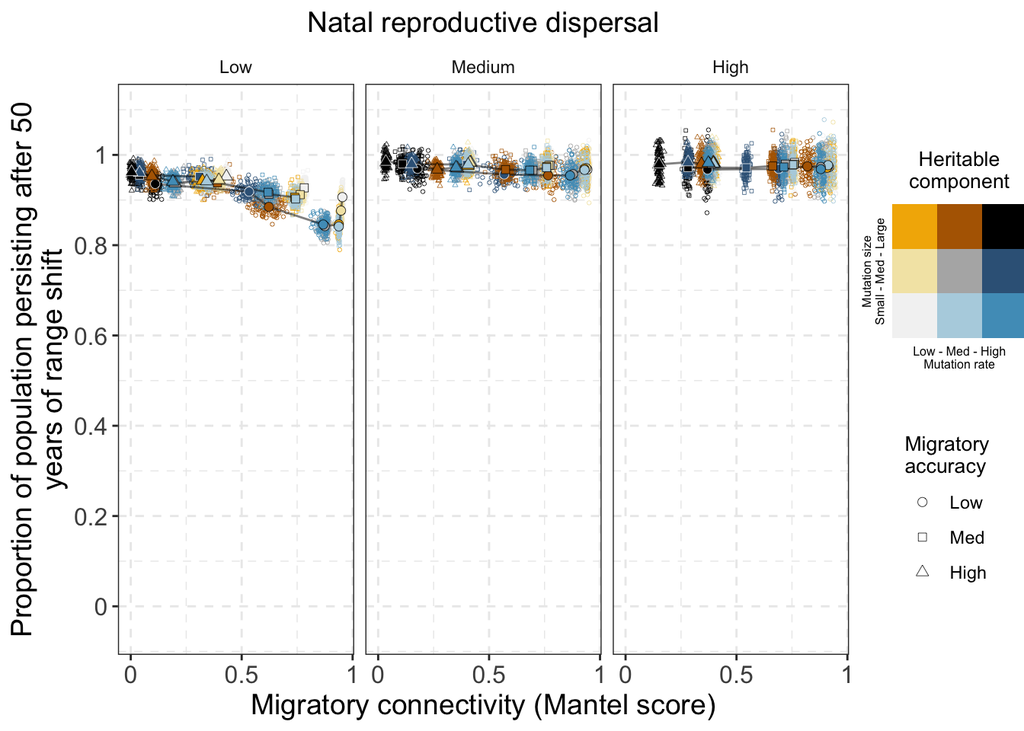

```r
facet_names2 <- c(low = "Low", Med = "Medium", High = "High")

p6 <- ggplot(start_dataT, aes(x = average_mant, y = mid_diff_pop, shape = nbd, colour = fill)) +
    labs(y = "Proportion of population persisting after 50\nyears of range shift",
        x = "Migratory connectivity (Mantel score)", shape = "Migratory\naccuracy",
        subtitle = "Natal reproductive dispersal") + facet_grid(~bd, labeller = as_labeller(facet_names2)) +
    geom_point(aes(fill = NA), size = 1, show.legend = F, stroke = 0.2) + geom_line(data = average_dataT,
    mapping = aes(x = average_mant, y = mid_diff_pop2, group = nbd), colour = "black",
    alpha = 0.5, se = F) + geom_point(data = average_dataT, mapping = aes(x = average_mant,
    y = mid_diff_pop2, fill = fill), size = 2, show.legend = T, colour = rep(rep(c(rep("black",
    5), rep("white", 4)), 3), 3), stroke = 0.2) + theme_bw() + scale_colour_identity() +
    scale_x_continuous(breaks = seq(0, 1, 0.5), labels = c(0, 0.5, 1)) + scale_y_continuous(breaks = seq(0,
    1, 0.2), labels = seq(0, 1, 0.2), limits = c(-0.05, 1.1)) + scale_fill_identity() +
    scale_shape_manual(values = c(21, 22, 24)) + theme(plot.subtitle = element_text(hjust = 0.5,
    size = 14), legend.title = element_text(size = 10), axis.title.y = element_text(size = 14),
    axis.title.x = element_text(size = 14), axis.text = element_text(size = 12),
    strip.background = element_rect(colour = NA, fill = NA), panel.grid.major.y = element_line(linetype = "dashed"),
    panel.grid.minor.y = element_line(linetype = "dashed"), panel.grid.major.x = element_line(linetype = "dashed"),
    panel.grid.minor.x = element_line(linetype = "dashed"))

p6_2 <- ggplot(start_dataT, aes(x = average_mant, y = mid_diff_pop, shape = nbd,
    colour = fill)) + labs(y = "Proportion of population persisting after 50\nyears of range shift",
    x = "Migratory connectivity (Mantel score)", shape = "Migratory\naccuracy", subtitle = "Natal reproductive dispersal") +
    facet_grid(~bd, labeller = as_labeller(facet_names2)) + geom_point(aes(fill = NA),
    size = 0.8, show.legend = F, stroke = 0.2) + geom_line(data = average_dataT,
    mapping = aes(x = average_mant, y = mid_diff_pop2, group = nbd), colour = "black",
    alpha = 0.5, se = F) + geom_point(data = average_dataT, mapping = aes(x = average_mant,
    y = mid_diff_pop2, fill = fill), size = 2, show.legend = T, colour = rep(rep(c(rep("black",
    7), rep("white", 2)), 3), 3), stroke = 0.2) + theme_bw() + scale_colour_identity() +
    scale_x_continuous(breaks = seq(0, 1, 0.5), labels = c(0, 0.5, 1)) + scale_y_continuous(breaks = seq(0,
    1, 0.2), labels = seq(0, 1, 0.2), limits = c(-0.05, 1.1)) + scale_fill_identity() +
    scale_shape_manual(values = c(21, 22, 24)) + theme(plot.subtitle = element_text(hjust = 0.5,
    size = 14), legend.title = element_text(size = 10), axis.title.y = element_text(size = 14),
    axis.title.x = element_text(size = 14), axis.text = element_text(size = 12),
    strip.background = element_rect(colour = NA, fill = NA), panel.grid.major.y = element_line(linetype = "dashed"),
    panel.grid.minor.y = element_line(linetype = "dashed"), panel.grid.major.x = element_line(linetype = "dashed"),
    panel.grid.minor.x = element_line(linetype = "dashed"), legend.position = "none")
# ggsave(plot=pU2, file='Figure 6.pdf', height=4.5,width=6.811, units = 'in')

p6_legend <- get_legend(p6)

(fig7 <- ggdraw() + draw_plot(p6_2, x = 0, y = 0, width = 0.84, height = 1) + draw_plot(legend,
    x = 0.75, y = 0.475, width = 0.35, height = 0.35) + draw_plot(p6_legend, x = 0.85,
    y = 0.225, width = 0.15, height = 0.15))
```

**Figure SM2:** Relationship between realised migratory connectivity and the persistence of populations under coupled shifts in seasonal habitat zones. Connectivity is measured as the Mantel correlation at the end of a 500-year burn-in period, prior to range-shift exposure. Points represent model runs for a given combination of the four drivers of dispersal (reproductive dispersal, migratory accuracy, migratory program mutation and size). Black outlined points indicate mean values for a given scenario.

## R Session Information

**R version 4.2.1 (2022-06-23)**

**Platform:** x86_64-apple-darwin17.0 (64-bit)

**locale:** en_GB.UTF-8||en_GB.UTF-8||en_GB.UTF-8||C||en_GB.UTF-8||en_GB.UTF-8

**attached base packages:** *stats*, *graphics*, *grDevices*, *utils*, *datasets*, *methods* and *base*

**other attached packages:** *scico(v.1.3.1)*, *kableExtra(v.1.3.4)*, *ggpubr(v.0.4.0)*, *rgeos(v.0.5-9)*, *ggrepel(v.0.9.1)*, *rnaturalearth(v.0.1.0)*, *pander(v.0.6.5)*, *formatR(v.1.12)*, *biscale(v.1.0.0)*, *plyr(v.1.8.7)*, *dplyr(v.1.0.10)*, *ggplot2(v.3.3.6)*, *cowplot(v.1.1.1)*, *sna(v.2.7)*, *network(v.1.18.0)*, *statnet.common(v.4.7.0)*, *tidyr(v.1.2.1)*, *data.table(v.1.14.2)*, *ade4(v.1.7-19)*, *geosphere(v.1.5-14)*, *raster(v.3.5-29)* and *sp(v.1.5-0)*

**loaded via a namespace (and not attached):** *sf(v.1.0-8)*, *webshot(v.0.5.3)*, *httr(v.1.4.4)*, *tools(v.4.2.1)*, *backports(v.1.4.1)*, *bslib(v.0.4.0)*, *utf8(v.1.2.2)*, *rgdal(v.1.5-32)*, *R6(v.2.5.1)*, *KernSmooth(v.2.23-20)*, *DBI(v.1.1.3)*, *colorspace(v.2.0-3)*, *withr(v.2.5.0)*, *tidyselect(v.1.1.2)*, *compiler(v.4.2.1)*, *cli(v.3.4.0)*, *rvest(v.1.0.3)*, *xml2(v.1.3.3)*, *labeling(v.0.4.2)*, *sass(v.0.4.2)*, *scales(v.1.2.1)*, *classInt(v.0.4-7)*, *proxy(v.0.4-27)*, *systemfonts(v.1.0.4)*, *stringr(v.1.4.1)*, *digest(v.0.6.29)*, *rmarkdown(v.2.16.1)*, *svglite(v.2.1.0)*, *pkgconfig(v.2.0.3)*, *htmltools(v.0.5.3)*, *highr(v.0.9)*, *fastmap(v.1.1.0)*, *rlang(v.1.0.5)*, *rstudioapi(v.0.14)*, *jquerylib(v.0.1.4)*, *generics(v.0.1.3)*, *farver(v.2.1.1)*, *jsonlite(v.1.8.0)*, *car(v.3.1-0)*, *magrittr(v.2.0.3)*, *Rcpp(v.1.0.9)*, *munsell(v.0.5.0)*, *fansi(v.1.0.3)*, *abind(v.1.4-5)*, *lifecycle(v.1.0.2)*, *terra(v.1.6-17)*, *stringi(v.1.7.8)*, *yaml(v.2.3.5)*, *carData(v.3.0-5)*, *MASS(v.7.3-58.1)*, *grid(v.4.2.1)*, *lattice(v.0.20-45)*, *knitr(v.1.40)*, *pillar(v.1.8.1)*, *ggsignif(v.0.6.3)*, *codetools(v.0.2-18)*, *glue(v.1.6.2)*, *evaluate(v.0.16)*, *vctrs(v.0.4.1)*, *gtable(v.0.3.1)*, *purrr(v.0.3.4)*, *assertthat(v.0.2.1)*, *cachem(v.1.0.6)*, *xfun(v.0.32)*, *broom(v.1.0.1)*, *e1071(v.1.7-11)*, *coda(v.0.19-4)*, *rstatix(v.0.7.0)*, *class(v.7.3-20)*, *viridisLite(v.0.4.1)*, *tibble(v.3.1.8)* and *units(v.0.8-0)*